## # Practical Machine Learning - Practical Machine Learning

title: “Practical Machine Learning - Practical Machine Learning” output: html_document: keep_md: true Author: IM, date 2015-06-23. Test —

## Introduction

This report describes the result of the project for the coursera project “practical machine learning”. The description of the project can be found here: https://class.coursera.org/predmachlearn-030/human_grading/view/courses/975199/assessments/4/submissions

The data for this project has come from this source: http://groupware.les.inf.puc-rio.br/har.

Using devices such as Jawbone Up, Nike FuelBand, and Fitbit it is now possible to collect a large amount of data about personal activity relatively inexpensively. In this project, data will be used from accelerometers on the belt, forearm, arm, and dumbell of 6 participants whowere asked to perform barbell lifts correctly and incorrectly in 5 different ways.

The goal of the project is to predict the manner in which they did the exercise. This is the “classe” variable in the training set. Any of the other variables might be used for the prediction.

The report should contain the following elements - describing how you built your model, - how you used cross validation, - what you think the expected out of sample error is, and - why you made the choices you did.

Finally, the evental prediction model will be used to predict 20 different test cases.

## Data

The training data for this project are available here:

https://d396qusza40orc.cloudfront.net/predmachlearn/pml-training.csv

The following steps were taken in processing the data

1. Download the file from the URL given above
2. Load the data loaded into R using the read.csv function

```r
# 1. Download the file
url<-"https://d396qusza40orc.cloudfront.net/predmachlearn/pml-training.csv"
csvFilename<-"pml-training.csv"
if (file.exists(csvFilename)!=TRUE){
  setInternet2(use = TRUE)
  download.file(url,csvFilename,mode="wb")
}
# 2. load the data (i.e. read.csv())
trainData <- read.csv(csvFilename, header = TRUE)
```

## Cleaning the data

First the data has to be cleaned from impurities such as NA data and the proper variables have to be selected.

Unfortunately, the project description is somewhat contradictive. The background section describes that the goal will be “to use data from accelerometers on the belt, forearm, arm, and dumbell.” Later, it states " You may use any of the other variables to predict with“.

This report will only use the variables from the accelerators. First the dataset is limited to the data of the accelerators alone which have the string “accel” in their name. Subsequently variables that mainly contain NA are removed.

```r
namesTrainData<-names(trainData)
# select columns with accelerators
colAccel<- grepl("accel",namesTrainData)
# remove columns with var which are almost all NA
trainDataSize<-dim(trainData)
colClean<-as.numeric(colSums(is.na(trainData)))/trainDataSize[1]<0.95
# combined
colCombined<-(colClean & colAccel )
namesTrainDataCombined<-namesTrainData[colCombined]
# add classe column

myVars<-c(namesTrainDataCombined,"classe")
# subset dataset
trainDataSub<-trainData[myVars]
dim(trainDataSub)
```

```
## [1] 19622    17
```

## Preliminary data analysis

To get a sense of the data, the following 4 figures show the acceleration per type ( total, x-component, y-component, z-component) to assess whether there are any clear relationships between these variables and the class.

```r
library(caret)
```

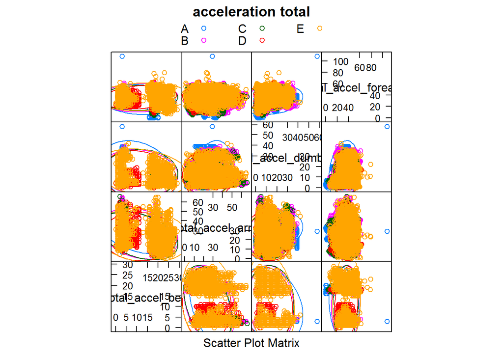

```r
library(kernlab)

posTotal<-grepl("total",names(trainDataSub))
featurePlot(x=trainDataSub[,posTotal],y=factor(trainDataSub$classe),
            plot="ellipse",auto.key = list(columns = 3),
            main = "acceleration total")
```

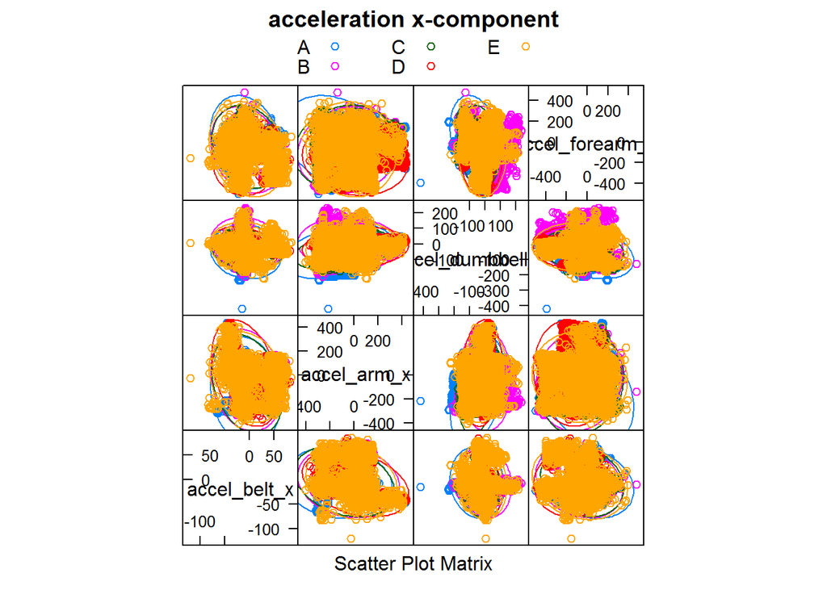

```r
posX<-grepl("_x",names(trainDataSub))
featurePlot(x=trainDataSub[,posX],y=factor(trainDataSub$classe),
            plot="ellipse",auto.key = list(columns = 3),
            main = "acceleration x-component")
```

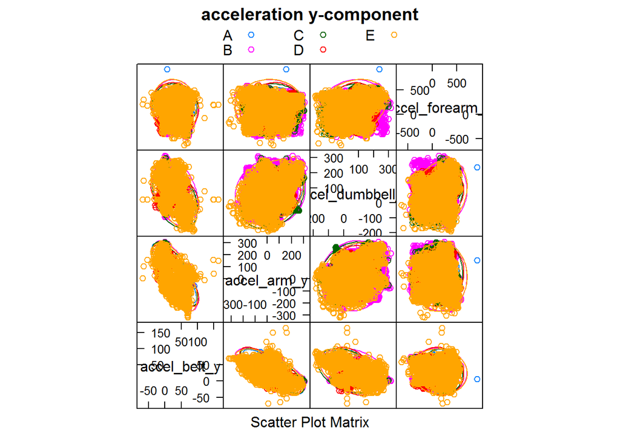

```r
posY<-grepl("_y",names(trainDataSub))
featurePlot(x=trainDataSub[,posY],y=factor(trainDataSub$classe),
            plot="ellipse",auto.key = list(columns = 3),
            main = "acceleration y-component")
```

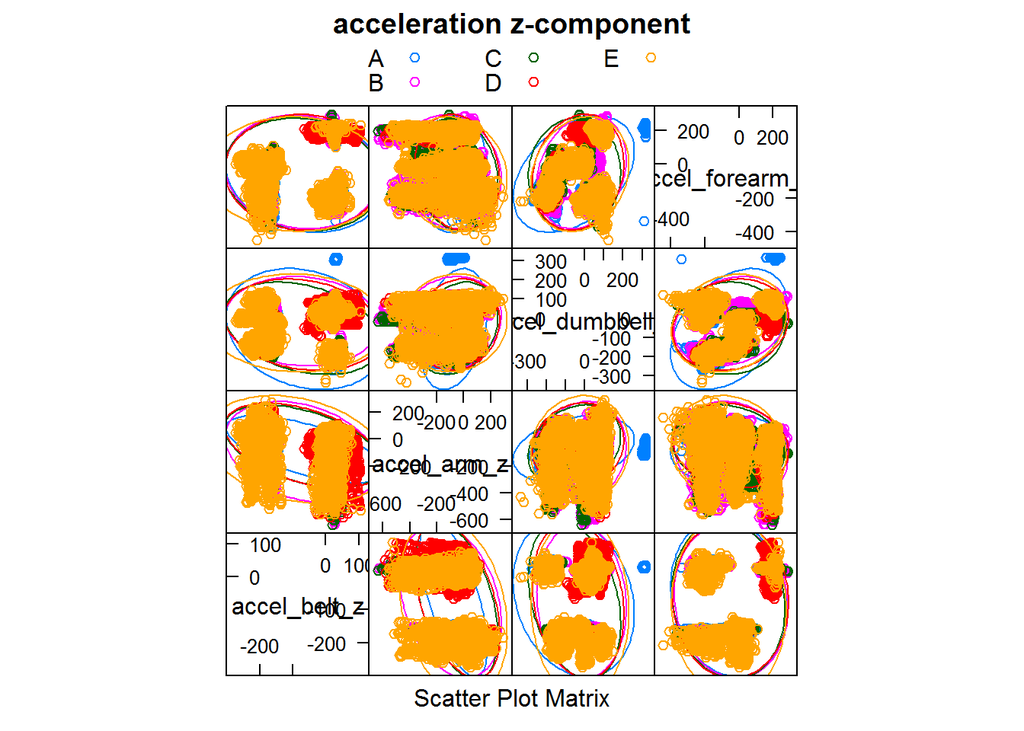

```r
posZ<-grepl("_z",names(trainDataSub))
featurePlot(x=trainDataSub[,posZ],y=factor(trainDataSub$classe),
            plot="ellipse",auto.key = list(columns = 3),
            main = "acceleration z-component")
```

From the plots, it is not really possible to see any relationship between the variables and the classe as there is a lot of overlap between all the classes. Hence, the relationship between the variables and the classes are likely to be nonlinear.

## Machine learning algorithm including cross-validation

This classification problem requires a machine learning algorithm that can predict multiple classes and that can handle non-linear data.

Therefore the choice has been made to use the random forest algorithm which is often very accurate.

A con of the random forest algorithm is the risk of overfitting. Therefore cross-validation is applied to assess the accuracy.

```r
# set the seed
set.seed(1235)
# do training on only part of the data to limit calculation time
smallTrain<-createDataPartition(y=trainDataSub$classe,p=0.5,list=FALSE)
trainDataSubSmall<-trainDataSub[smallTrain,]
# fit the model using Random Forest and Cross validation
modelFit<-train(as.factor(classe)~.,data=trainDataSubSmall, method="rf",
                trControl=trainControl(method="cv",number=5),
                prox=TRUE,allowParallel=TRUE)
# print the results
print(modelFit)
```

```
## Random Forest
##
## 9812 samples
##   16 predictor
##    5 classes: 'A', 'B', 'C', 'D', 'E'
##
## No pre-processing
## Resampling: Cross-Validated (5 fold)
## Summary of sample sizes: 7850, 7850, 7850, 7848, 7850
## Resampling results across tuning parameters:
##
##   mtry  Accuracy   Kappa      Accuracy SD  Kappa SD
##    2    0.9252960  0.9054233  0.006615424  0.008386669
##    9    0.9172432  0.8952596  0.007645891  0.009659612
##   16    0.9008366  0.8744769  0.007107128  0.009014303
##
## Accuracy was used to select the optimal model using  the largest value.
## The final value used for the model was mtry = 2.
```

```r
print(modelFit$finalModel)
```

```
##
## Call:
##  randomForest(x = x, y = y, mtry = param$mtry, proximity = TRUE,      allowParallel = TRUE)
##                Type of random forest: classification
##                      Number of trees: 500
## No. of variables tried at each split: 2
##
##         OOB estimate of  error rate: 6.48%
## Confusion matrix:
##      A    B    C    D    E class.error
## A 2671   24   44   50    1  0.04265233
## B   93 1706   63   19   18  0.10163244
## C   38   52 1605   13    3  0.06195207
## D   46    8   69 1470   15  0.08582090
## E    9   33   14   24 1724  0.04434590
```

## Expected out-of sample error.

From the final model, the estimate of the out of sample error is 6.48 %. Since the training was done on a subset of the data, it is possible to confirm this estimate with the remainder of the training data.

```r
# do training on only part of the data to limit calculation time
crossDataSubSmall<-trainDataSub[-smallTrain,]
crossDim<-dim(crossDataSubSmall)
# predict the model on the data not used in thre training set
crossPred<-predict(modelFit,crossDataSubSmall)
crossDataSubSmall$predRight<-crossPred==crossDataSubSmall$classe
crossAcc<-sum(crossDataSubSmall$predRight)/crossDim[1]*100
crossAccError<- 100 - crossAcc
confusionMatrix(crossPred,crossDataSubSmall$classe)
```

```
## Confusion Matrix and Statistics
##
##           Reference
## Prediction    A    B    C    D    E
##          A 2666   85   33   38    2
##          B   11 1696   48    9   32
##          C   47   83 1599   72    9
##          D   64   21   24 1485   17
##          E    2   13    7    4 1743
##
## Overall Statistics
##
##                Accuracy : 0.9367
##                  95% CI : (0.9317, 0.9414)
##     No Information Rate : 0.2844
##     P-Value [Acc > NIR] : < 2.2e-16
##
##                   Kappa : 0.9199
##  Mcnemar's Test P-Value : < 2.2e-16
##
## Statistics by Class:
##
##                      Class: A Class: B Class: C Class: D Class: E
## Sensitivity            0.9556   0.8936   0.9345   0.9235   0.9667
## Specificity            0.9775   0.9874   0.9739   0.9846   0.9968
## Pos Pred Value         0.9441   0.9443   0.8834   0.9218   0.9853
## Neg Pred Value         0.9823   0.9748   0.9860   0.9850   0.9925
## Prevalence             0.2844   0.1935   0.1744   0.1639   0.1838
## Detection Rate         0.2718   0.1729   0.1630   0.1514   0.1777
## Detection Prevalence   0.2879   0.1831   0.1845   0.1642   0.1803
## Balanced Accuracy      0.9665   0.9405   0.9542   0.9541   0.9817
```

The error of the cross-validation is 6.3302752 %.

## Test set

The trained machine learning algorithm also has to be applied to the 20 test cases available . The predictions have to be submitted in the appropriate format using for instance the function given in the programming assignment.

The test data are available here:

https://d396qusza40orc.cloudfront.net/predmachlearn/pml-testing.csv

```r
# a. Download the file
urlt<-"https://d396qusza40orc.cloudfront.net/predmachlearn/pml-testing.csv"
csvFilenamet<-"pml-testing.csv"
if (file.exists(csvFilenamet)!=TRUE){
  setInternet2(use = TRUE)
  download.file(urlt,csvFilenamet,mode="wb")
}
# b. load the data (i.e. read.csv())
testData <- read.csv(csvFilenamet, header = TRUE)
# run the prediction
pred <- predict(modelFit, testData)
# function to write to file from the programming assignment
#
pml_write_files = function(x){
  n = length(x)
  for(i in 1:n){
    filename = paste0("problem_id_",i,".txt")
    write.table(x[i],file=filename,quote=FALSE,row.names=FALSE,col.names=FALSE)
  }
}
predc<-as.character(pred)
pml_write_files(predc)
```